# Untitled

2026-06-01

Getting pressure layers for vessel traffic.

```r
library(tidyverse)
library(here)
library(terra)
library(sf)
library(paletteer)

ohi_marine <- rast(here("spatial/ohi_regions/ohi_marine_raster_1km.tif"))
ohi_marine <- ifel(ohi_marine>=1, 1, NA)

PRESSURE_ROOT <- "/home/shares/ohi/OHI_GOC/goal_prep/pressures/vessels"
```

Some raster functions

```r
VMS_ROOT <- "/home/shares/ohi/OHI_GOC/_raw_data/vms_juan_carlos"
CAP_YEAR <- 2024L
YEAR_MIN <- 2007L
YEAR_MAX <- 2025L
HOURS_CAP <- 3

load_vms_year <- function(year) {
  vms_path <- file.path(VMS_ROOT, "vms", sprintf("vms_%s.csv", year))
  if (!file.exists(vms_path)) stop("Missing VMS file: ", vms_path)

  read_csv(vms_path, show_col_types = FALSE) %>%
    select(-name, -port, -economic_unit) %>%
    left_join(vessels, by = "vessel_rnpa")  # uses GoC-filtered registry from chunk above
}

filter_vessel_traffic <- function(vms_year) {
  vms_year %>%
    filter(!is.na(hours), hours > 0) %>%
    mutate(hours = pmin(hours, HOURS_CAP)) %>%
    filter(!is.na(lat), !is.na(lon))
}

rasterize_to_marine <- function(pings, field, layer_name) {
  pings_sf <- pings %>%
    st_as_sf(coords = c("lon", "lat"), crs = 4326, remove = FALSE) %>%
    st_transform(crs(ohi_marine))

  out <- rasterize(
    vect(pings_sf),
    y = ohi_marine,
    field = field,
    fun = "sum",
    background = 0
  )
  out <- ifel(is.na(ohi_marine), NA, out)
  names(out) <- layer_name
  out
}

write_pressure_pair <- function(r, uncapped_path, capped_path, cap_value) {
  dir.create(dirname(uncapped_path), recursive = TRUE, showWarnings = FALSE)
  writeRaster(r, uncapped_path, overwrite = TRUE)
  writeRaster(ifel(r > cap_value, cap_value, r), capped_path, overwrite = TRUE)
}
```

# Pressure 1: General vessel traffic

Used for noise and strike risk. Only includes fishing vessels. Ideally this should be supplemented with other data that includes tour ships, etc.

## 2024 VMS exploration

```r
vessels <- read_csv("/home/shares/ohi/OHI_GOC/_raw_data/vms_juan_carlos/vessel.csv") %>%
  filter(state %in% c("BAJA CALIFORNIA", "BAJA CALIFORNIA SUR", "JALISCO",
                      "NAYARIT", "SINALOA", "SONORA"))
vms <- read_csv("/home/shares/ohi/OHI_GOC/_raw_data/vms_juan_carlos/vms/vms_2024.csv") %>%
  select(-name, -port, -economic_unit)
```

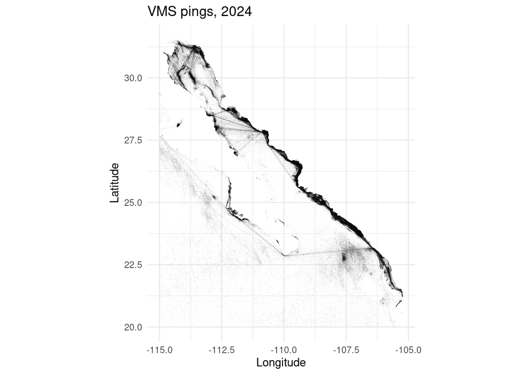

```r
vessel_pressure <- left_join(vms, vessels, by=c("vessel_rnpa"))

ggplot(vessel_pressure, aes(x = lon, y = lat)) +
  geom_point(alpha = 0.05, size = 0.15, stroke = 0) +
  coord_fixed() +
  labs(
    title = "VMS pings, 2024",
    x = "Longitude",
    y = "Latitude"
  ) +
  theme_minimal()
```

## Build yearly vessel-traffic GeoTIFFs (Pressure 1 only).

## Sum of VMS hours per 1 km cell; hours capped at 3 h per ping.

## Capped rasters use the 2024 99th-percentile value (fixed across years).

```r
## Cap from 2024
message("Computing 99th-percentile cap from ", CAP_YEAR, " (vessel traffic)")
pings_cap <- load_vms_year(CAP_YEAR) %>% filter_vessel_traffic()
r_cap <- rasterize_to_marine(pings_cap, "hours", "hours_count")
q99_vessel <- as.numeric(quantile(values(r_cap), 0.99, na.rm = TRUE))
message("Vessel traffic 99th-percentile cap: ", signif(q99_vessel, 4))

## All years
years <- YEAR_MIN:YEAR_MAX
walk(years, function(year) {
  message("\n=== Vessel traffic year ", year, " ===")
  pings <- load_vms_year(year) %>% filter_vessel_traffic()
  r <- rasterize_to_marine(pings, "hours", "hours_count")
  uncapped <- file.path(PRESSURE_ROOT, "vessel_traffic", sprintf("vms_hours_%s_1km.tif", year))
  capped <- file.path(PRESSURE_ROOT, "vessel_traffic", sprintf("vms_hours_%s_1km_capped.tif", year))
  write_pressure_pair(r, uncapped, capped, q99_vessel)
  message("Wrote ", basename(uncapped), " and ", basename(capped))
})

message("\nDone. Wrote ", length(years), " years of vessel traffic rasters (uncapped + capped).")
```

Sum of VMS hours per 1 km cell, aligned to `ohi_marine_raster_1km.tif` (EPSG:6372). Written by the chunk above (also available via `scripts/build_vessel_pressure_rasters.R`).

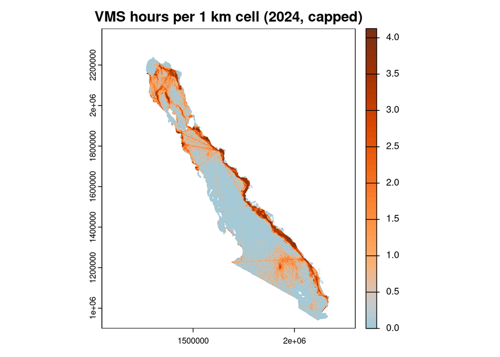

```r
hours_count <- rast(file.path(
  PRESSURE_ROOT,
  "vessel_traffic",
  "vms_hours_2024_1km_capped.tif"
))

colors <- paletteer_c("ggthemes::Classic Orange-Blue", 100)[1:55]
plot(log1p(hours_count), main = "VMS hours per 1 km cell (2024, capped)", col = rev(colors))
```

# Pressure 2: demersal destructive fishing pressure

## Gear type × target species combinations

All unique pairs in the GoC vessel registry (six states), with vessel counts. `bottom_destructive` flags combinations likely to include **bottom trawling** with benthic impact (permit-level inference). Rules:

- **Sardine/anchovy** never bottom trawl, even if the gear is arrastre.
- **Tuna without shrimp** never bottom trawl, even if the gear is arrastre and escama is also listed. That permit can be a midwater trawl.
- **Shrimp** is bottom trawl, including when the gear is `OTRO`, missing, `PESCA MULTIPLE`, longline, purse seine, or pole-and-line. Those boats match the industrial shrimp-trawl fleet.
- `NA` + `NA` is unclassified (`bottom_destructive` = NA → excluded from bottom-trawl layers).

```r
gear_target_combos <- vessels %>%
  count(gear_type, target_species, name = "n_vessels", .drop = FALSE) %>%
  mutate(
    gear_chr = coalesce(gear_type, ""),
    target_chr = coalesce(target_species, ""),
    has_trawl = str_detect(gear_chr, "ARRASTRE"),
    has_purse_seine = str_detect(gear_chr, "CERCO"),
    has_longline = str_detect(gear_chr, "PALANGRE"),
    has_pesca_multiple = gear_chr == "PESCA MULTIPLE",
    has_shrimp_target = str_detect(target_chr, "CAMARÓN"),
    has_finfish_target = str_detect(target_chr, "ESCAMA"),
    has_sardine_target = str_detect(target_chr, "SARDINA"),
    has_tuna_target = str_detect(target_chr, "ATÚN"),
    has_shark_target = str_detect(target_chr, "TIBURÓN"),
    has_tuna_only = has_tuna_target & !has_shrimp_target & !has_finfish_target &
      !has_shark_target & !has_sardine_target,
    has_otras_target = str_detect(target_chr, "OTRAS"),
    gear_missing = is.na(gear_type) | gear_chr == "",
    target_missing = is.na(target_species) | target_chr == "",
    ambiguous_gear = gear_missing | gear_chr == "OTRO" | has_pesca_multiple,
    bottom_destructive = case_when(
      gear_missing & target_missing ~ NA,
      ## Sardine/anchovy: never bottom trawl (even if ARRASTRE on permit)
      has_sardine_target ~ FALSE,
      ## Tuna without shrimp: never bottom trawl, even if arrastre also lists escama
      has_tuna_target & !has_shrimp_target ~ FALSE,
      ## Shrimp + ambiguous gear (OTRO, NA gear, PESCA MULTIPLE): treat as bottom trawl
      has_shrimp_target & ambiguous_gear ~ TRUE,
      ## Trawl on permit (non-sardine, non-tuna targets)
      has_trawl ~ TRUE,
      ## Shrimp on longline, purse seine, or pole-and-line: same industrial trawl fleet
      has_shrimp_target ~ TRUE,
      ## Pelagic / hook gear without trawl
      !has_trawl & (has_purse_seine | has_longline) ~ FALSE,
      ## Unspecified buckets without shrimp
      !has_trawl & (gear_chr == "OTRO" | has_otras_target) ~ FALSE,
      TRUE ~ FALSE
    ),
    confidence = case_when(
      gear_missing & target_missing ~ NA_character_,
      has_sardine_target ~ "high",
      has_tuna_only ~ "high",
      has_shrimp_target & ambiguous_gear ~ "low",
      has_trawl & has_shrimp_target & !has_longline & !has_pesca_multiple ~ "high",
      has_trawl & has_shrimp_target ~ "medium",
      has_trawl & has_finfish_target & !has_shrimp_target ~ "medium",
      has_trawl ~ "medium",
      has_shrimp_target ~ "high",
      !has_trawl & (has_purse_seine | has_longline) ~ "high",
      !has_trawl & gear_chr == "OTRO" & has_otras_target ~ "high",
      !has_trawl & (has_tuna_target) & !has_shrimp_target ~ "high",
      TRUE ~ "high"
    )
  ) %>%
  select(-gear_chr, -target_chr, -has_trawl, -has_purse_seine, -has_longline,
         -has_pesca_multiple, -has_shrimp_target, -has_finfish_target,
         -has_sardine_target, -has_tuna_target, -has_shark_target, -has_tuna_only,
         -has_otras_target,
         -gear_missing, -target_missing, -ambiguous_gear) %>%
  arrange(desc(n_vessels), gear_type, target_species)

dir.create(here("_pressures/vessels/data"), recursive = TRUE, showWarnings = FALSE)
write_csv(
  gear_target_combos,
  here("_pressures/vessels/data/gear_target_benthic_destructive.csv")
)

gear_target_combos
```

```
## # A tibble: 127 × 5
##    gear_type target_species      n_vessels bottom_destructive confidence
##    <chr>     <chr>                   <int> <lgl>              <chr>
##  1 ARRASTRE  CAMARÓN                   652 TRUE               high
##  2 <NA>      <NA>                      222 NA                 <NA>
##  3 ARRASTRE  CAMARÓN | ESCAMA          136 TRUE               high
##  4 CERCO     SARDINA Y ANCHOVETA        82 FALSE              high
##  5 OTRO      OTRAS                      74 FALSE              high
##  6 ARRASTRE  CAMARÓN | OTRAS            71 TRUE               high
##  7 CERCO     ATÚN                       43 FALSE              high
##  8 OTRO      CAMARÓN                    38 TRUE               low
##  9 <NA>      CAMARÓN                    38 TRUE               low
## 10 ARRASTRE  CAMARÓN | TIBURÓN          21 TRUE               high
## # ℹ 117 more rows
```

## Get 99th-percentile cap value (from 2024)

### Filter pings for potential bottom-destructive trawling

Keep VMS pings that plausibly reflect **bottom trawling**, using permit metadata (`gear_target_combos`) and speed. Depth is not a cutoff. Each step below drops pings that fail that step; the table shows how many rows remain.

**Permit rule:** we only require a **`bottom_destructive` assessment** on the permit (gear × target combo). Pings are dropped when `bottom_destructive` is **NA** (unclassified combo, mainly missing gear and target). We do **not** drop pings solely because `gear_type` or `target_species` is missing if the combo still has `bottom_destructive` TRUE or FALSE (e.g. shrimp with inferred bottom trawl when gear is `OTRO` or missing).

**Also applied:** each ping’s `hours` is capped at **3 h** before summing (limits inflation from long gaps between VMS reports).

```r
## Shared by bottom-trawl and ghost-pressure filter chunks.
filter_step <- function(label, n_in, n_out) {
  message(
    sprintf(
      "%s: %s → %s pings (removed %s)",
      label,
      format(n_in, big.mark = ","),
      format(n_out, big.mark = ","),
      format(n_in - n_out, big.mark = ",")
    )
  )
}
```

```r
## Lookup: one row per gear + target combination (from registry, not from VMS pings).
destructive_lookup <- gear_target_combos %>%
  select(gear_type, target_species, bottom_destructive)

## Attach permit-based bottom-trawl flag to every ping.
pings_with_permit <- vessel_pressure %>%
  left_join(destructive_lookup, by = c("gear_type", "target_species"))

n_start <- nrow(pings_with_permit)

## 1) Drop pings with no bottom_destructive assessment (NA on permit combo).
pings_assessed <- pings_with_permit %>%
  filter(!is.na(bottom_destructive))
filter_step("1. bottom_destructive assessed (not NA)", n_start, nrow(pings_assessed))
```

```
## 1. bottom_destructive assessed (not NA): 1,248,398 → 1,187,436 pings (removed 60,962)
```

```r
## 2) Keep only permit combinations classified as bottom-destructive (see gear_target_combos chunk).
pings_destructive <- pings_assessed %>%
  filter(bottom_destructive == TRUE)
filter_step("2. Bottom-destructive permit combo", nrow(pings_assessed), nrow(pings_destructive))
```

```
## 2. Bottom-destructive permit combo: 1,187,436 → 730,707 pings (removed 456,729)
```

```r
## 3) Drop fast transit legs (speed between consecutive pings, in knots).
## No depth cutoff: pings deeper than 100 m stay in the layer.
pings_trawling_speed <- pings_destructive %>%
  filter(!is.na(implied_speed_knots), implied_speed_knots <= 6)
filter_step("3. Implied speed ≤ 6 knots", nrow(pings_destructive), nrow(pings_trawling_speed))
```

```
## 3. Implied speed ≤ 6 knots: 730,707 → 650,167 pings (removed 80,540)
```

```r
## 4) Valid positions and positive time step (for later sum(hours) rasters).
pings_valid <- pings_trawling_speed %>%
  filter(!is.na(lat), !is.na(lon), !is.na(hours), hours > 0)

filter_step("4. Valid lat/lon and hours > 0", nrow(pings_trawling_speed), nrow(pings_valid))
```

```
## 4. Valid lat/lon and hours > 0: 650,167 → 650,167 pings (removed 0)
```

```r
## 5) Cap hours at 3 h so one long gap between pings cannot add >3 vessel-hours to a cell.
n_capped <- sum(pings_valid$hours > 3, na.rm = TRUE)

vessel_pressure_bottom <- pings_valid %>%
  mutate(hours = pmin(hours, 3))

message(
  sprintf(
    "5. Cap hours at 3 h: %s pings had hours > 3 before cap (all %s rows kept)",
    format(n_capped, big.mark = ","),
    format(nrow(vessel_pressure_bottom), big.mark = ",")
  )
)
```

```
## 5. Cap hours at 3 h: 534 pings had hours > 3 before cap (all 650,167 rows kept)
```

```r
## Summary table
tibble(
  step = c(
    "All pings (with bottom_destructive joined)",
    "After: bottom_destructive assessed (not NA)",
    "After: bottom-destructive permit (TRUE)",
    "After: speed ≤ 6 kn",
    "After: valid position and hours > 0",
    "Final: hours capped at 3 h per ping"
  ),
  n_pings = c(
    n_start,
    nrow(pings_assessed),
    nrow(pings_destructive),
    nrow(pings_trawling_speed),
    nrow(pings_valid),
    nrow(vessel_pressure_bottom)
  ),
  pct_of_start = round(100 * c(
    n_start,
    nrow(pings_assessed),
    nrow(pings_destructive),
    nrow(pings_trawling_speed),
    nrow(pings_valid),
    nrow(vessel_pressure_bottom)
  ) / n_start, 1)
)
```

```
## # A tibble: 6 × 3
##   step                                        n_pings pct_of_start
##   <chr>                                         <int>        <dbl>
## 1 All pings (with bottom_destructive joined)  1248398        100
## 2 After: bottom_destructive assessed (not NA) 1187436         95.1
## 3 After: bottom-destructive permit (TRUE)      730707         58.5
## 4 After: speed ≤ 6 kn                          650167         52.1
## 5 After: valid position and hours > 0          650167         52.1
## 6 Final: hours capped at 3 h per ping          650167         52.1
```

```r
vessel_pressure_bottom
```

```
## # A tibble: 650,167 × 62
##    vessel_rnpa src     seg_id point_in_seg datetime              lat   lon   sea
##    <chr>       <chr>   <chr>         <dbl> <dttm>              <dbl> <dbl> <dbl>
##  1 00056002    09-SEP… 00056…        48887 2024-09-30 16:13:00  24.8 -113.     6
##  2 00056002    10-OCT… 00056…        48909 2024-10-01 14:13:00  24.7 -113.     6
##  3 00020743    02-FEB… 00020…        38535 2024-02-17 06:23:00  30.2 -113.     6
##  4 00020743    08-AGO… 00020…        41060 2024-08-19 20:32:00  26.8 -110.     6
##  5 00022749    04-ABR… 00022…        25891 2024-04-19 04:54:00  30.8 -115.     6
##  6 00023739    01-ENE… 00023…        34099 2024-01-18 00:03:00  28.7 -112.     6
##  7 00038166    11-NOV… 00038…        38022 2024-11-21 13:49:00  28.8 -112.     6
##  8 00041046    12-DIC… 00041…        37438 2024-12-05 21:19:00  28.3 -112.     6
##  9 00041434    03-MAR… 00041…        49229 2024-03-13 13:10:00  25.9 -109.     6
## 10 00041434    10-OCT… 00041…        49711 2024-10-30 20:29:00  28.4 -112.     6
## # ℹ 650,157 more rows
## # ℹ 54 more variables: eez <dbl>, mpa <dbl>, fishing_region <dbl>,
## #   distance_from_port_m <dbl>, distance_from_shore_m <dbl>, depth_m <dbl>,
## #   reported_speed <dbl>, course <dbl>, year <dbl>, month <dbl>,
## #   distance_to_last_m <dbl>, hours <dbl>, implied_speed_knots <dbl>,
## #   eu_rnpa <chr>, eu_name <chr>, vessel_name <chr>, owner_rnpa <chr>,
## #   owner_name <chr>, hull_identifier <chr>, target_species <chr>, …
```

```r
### Want to get median speeds of bottom trawling for pressure
quantile(vessel_pressure_bottom$reported_speed, c(0.1, 0.5, 0.9), na.rm=TRUE)
```

```
##   10%   50%   90%
## 0.097 2.022 2.896
```

## Build yearly bottom-destructive GeoTIFFs (Pressure 2 only).

## Same filters as above: permit TRUE, implied speed ≤ 6 kn, hours capped at 3 h.

## No depth cutoff. Capped rasters use the 2024 99th-percentile value.

```r
destructive_lookup <- gear_target_combos %>%
  select(gear_type, target_species, bottom_destructive)

filter_bottom_destructive <- function(vms_year) {
  vms_year %>%
    left_join(destructive_lookup, by = c("gear_type", "target_species")) %>%
    filter(!is.na(bottom_destructive), bottom_destructive == TRUE) %>%
    filter(!is.na(implied_speed_knots), implied_speed_knots <= 6) %>%
    filter(!is.na(lat), !is.na(lon), !is.na(hours), hours > 0) %>%
    mutate(hours = pmin(hours, HOURS_CAP))
}

message("Computing 99th-percentile cap from ", CAP_YEAR, " (bottom-destructive fishing)")
```

```
## Computing 99th-percentile cap from 2024 (bottom-destructive fishing)
```

```r
pings_cap <- load_vms_year(CAP_YEAR) %>% filter_bottom_destructive()
r_cap <- rasterize_to_marine(pings_cap, "hours", "bottom_trawl_hours")
q99_bottom <- as.numeric(quantile(values(r_cap), 0.99, na.rm = TRUE))
message("Bottom-destructive 99th-percentile cap: ", signif(q99_bottom, 4))
```

```
## Bottom-destructive 99th-percentile cap: 48
```

```r
years <- YEAR_MIN:YEAR_MAX
walk(years, function(year) {
  message("\n=== Bottom-destructive year ", year, " ===")
  pings <- load_vms_year(year) %>% filter_bottom_destructive()
  r <- rasterize_to_marine(pings, "hours", "bottom_trawl_hours")
  uncapped <- file.path(
    PRESSURE_ROOT,
    "benthic_destructive_fishing",
    sprintf("destructive_fishing_hours_%s_1km.tif", year)
  )
  capped <- file.path(
    PRESSURE_ROOT,
    "benthic_destructive_fishing",
    sprintf("destructive_fishing_hours_%s_1km_capped.tif", year)
  )
  write_pressure_pair(r, uncapped, capped, q99_bottom)
  message("Wrote ", basename(uncapped), " and ", basename(capped))
})
```

```
##
## === Bottom-destructive year 2007 ===
```

```
## Wrote destructive_fishing_hours_2007_1km.tif and destructive_fishing_hours_2007_1km_capped.tif
```

```
##
## === Bottom-destructive year 2008 ===
```

```
## Wrote destructive_fishing_hours_2008_1km.tif and destructive_fishing_hours_2008_1km_capped.tif
```

```
##
## === Bottom-destructive year 2009 ===
```

```
## Wrote destructive_fishing_hours_2009_1km.tif and destructive_fishing_hours_2009_1km_capped.tif
```

```
##
## === Bottom-destructive year 2010 ===
```

```
## Wrote destructive_fishing_hours_2010_1km.tif and destructive_fishing_hours_2010_1km_capped.tif
```

```
##
## === Bottom-destructive year 2011 ===
```

```
## Wrote destructive_fishing_hours_2011_1km.tif and destructive_fishing_hours_2011_1km_capped.tif
```

```
##
## === Bottom-destructive year 2012 ===
```

```
## Wrote destructive_fishing_hours_2012_1km.tif and destructive_fishing_hours_2012_1km_capped.tif
```

```
##
## === Bottom-destructive year 2013 ===
```

```
## Wrote destructive_fishing_hours_2013_1km.tif and destructive_fishing_hours_2013_1km_capped.tif
```

```
##
## === Bottom-destructive year 2014 ===
```

```
## Wrote destructive_fishing_hours_2014_1km.tif and destructive_fishing_hours_2014_1km_capped.tif
```

```
##
## === Bottom-destructive year 2015 ===
```

```
## Wrote destructive_fishing_hours_2015_1km.tif and destructive_fishing_hours_2015_1km_capped.tif
```

```
##
## === Bottom-destructive year 2016 ===
```

```
## Wrote destructive_fishing_hours_2016_1km.tif and destructive_fishing_hours_2016_1km_capped.tif
```

```
##
## === Bottom-destructive year 2017 ===
```

```
## Wrote destructive_fishing_hours_2017_1km.tif and destructive_fishing_hours_2017_1km_capped.tif
```

```
##
## === Bottom-destructive year 2018 ===
```

```
## Wrote destructive_fishing_hours_2018_1km.tif and destructive_fishing_hours_2018_1km_capped.tif
```

```
##
## === Bottom-destructive year 2019 ===
```

```
## Wrote destructive_fishing_hours_2019_1km.tif and destructive_fishing_hours_2019_1km_capped.tif
```

```
##
## === Bottom-destructive year 2020 ===
```

```
## Wrote destructive_fishing_hours_2020_1km.tif and destructive_fishing_hours_2020_1km_capped.tif
```

```
##
## === Bottom-destructive year 2021 ===
```

```
## Wrote destructive_fishing_hours_2021_1km.tif and destructive_fishing_hours_2021_1km_capped.tif
```

```
##
## === Bottom-destructive year 2022 ===
```

```
## Wrote destructive_fishing_hours_2022_1km.tif and destructive_fishing_hours_2022_1km_capped.tif
```

```
##
## === Bottom-destructive year 2023 ===
```

```
## Wrote destructive_fishing_hours_2023_1km.tif and destructive_fishing_hours_2023_1km_capped.tif
```

```
##
## === Bottom-destructive year 2024 ===
```

```
## Wrote destructive_fishing_hours_2024_1km.tif and destructive_fishing_hours_2024_1km_capped.tif
```

```
##
## === Bottom-destructive year 2025 ===
```

```
## Wrote destructive_fishing_hours_2025_1km.tif and destructive_fishing_hours_2025_1km_capped.tif
```

```r
message("\nDone. Wrote ", length(years), " years of bottom-destructive rasters (uncapped + capped).")
```

```
##
## Done. Wrote 19 years of bottom-destructive rasters (uncapped + capped).
```

## Bottom-destructive trawl effort raster (2024, from GeoTIFF)

Sum of capped **`hours`** per 1 km cell for filtered pings (`vessel_pressure_bottom`). Written by the chunk above (also available via `scripts/build_vessel_pressure_rasters.R`).

```r
bottom_trawl_hours <- rast(file.path(
  PRESSURE_ROOT,
  "benthic_destructive_fishing",
  "destructive_fishing_hours_2024_1km.tif"
))

hours_in_pings <- sum(vessel_pressure_bottom$hours, na.rm = TRUE)
hours_in_raster <- global(bottom_trawl_hours, "sum", na.rm = TRUE)[1, 1]
message(
  "Sum of hours in pings: ", format(round(hours_in_pings), big.mark = ","),
  " | Sum in raster: ", format(round(hours_in_raster), big.mark = ",")
)
```

```
## Sum of hours in pings: 647,453 | Sum in raster: 605,532
```

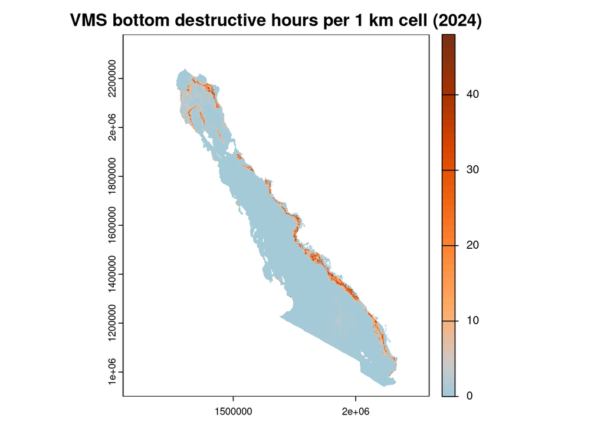

```r
colors <- paletteer_c("ggthemes::Classic Orange-Blue", 100)[1:55]
q99_bd <- quantile(values(bottom_trawl_hours), 0.99, na.rm = TRUE)
plot(
  ifel(bottom_trawl_hours > q99_bd, 1, bottom_trawl_hours),
  main = "VMS bottom destructive hours per 1 km cell (2024)",
  col = rev(colors)
)
```

# Pressure 3: Ghost gear risk

Attach Gilman et al. (2021) scores to **every VMS ping** via the vessel permit (`gear_type` + `target_species`). Crosswalk: `data/gear_gilman_crosswalk.csv` (built from `data/gear_target_benthic_destructive.csv` via `build_gilman_crosswalk.Rmd`).

**Per-ping score:** `ghost_gear_risk` = `H_gear_ghost` = **R × ghost_fishing_mean** (Table 2 ALDFG leakage rate **R** × Supplement Table S2 ghost-fishing mean). This is **not** `H_gear × ghost_fishing_mean` (that would multiply in Table 2 outcome **O** as well). `H_gear` = R × O is the general gear hazard index; we use the ghost-specific index only.

Pings whose permit has **both** gear and target missing stay **NA** (unclassified combo in the crosswalk).

```r
gilman_by_permit <- read_csv(
  here("_pressures/vessels/data/gear_gilman_crosswalk.csv"),
  show_col_types = FALSE
) %>%
  select(
    gear_type,
    target_species,
    gilman_gear = gilman_gear_category,
    gilman_R = R,
    ghost_fishing_mean,
    H_gear_ghost)

gilman_by_permit
```

```
## # A tibble: 127 × 6
##    gear_type target_species gilman_gear gilman_R ghost_fishing_mean H_gear_ghost
##    <chr>     <chr>          <chr>          <dbl>              <dbl>        <dbl>
##  1 ARRASTRE  CAMARÓN        Trawl, bot…    0.16              0.667        0.107
##  2 <NA>      <NA>           <NA>          NA                NA           NA
##  3 ARRASTRE  CAMARÓN | ESC… Trawl, bot…    0.16              0.667        0.107
##  4 CERCO     SARDINA Y ANC… Purse sein…    0.07              0.0667       0.0047
##  5 OTRO      OTRAS          Hand dredg…    0.001             0            0
##  6 ARRASTRE  CAMARÓN | OTR… Trawl, bot…    0.16              0.667        0.107
##  7 CERCO     ATÚN           Purse sein…    0.75              0.6          0.45
##  8 OTRO      CAMARÓN        Trawl, bot…    0.16              0.667        0.107
##  9 <NA>      CAMARÓN        Trawl, bot…    0.16              0.667        0.107
## 10 ARRASTRE  CAMARÓN | TIB… Trawl, bot…    0.16              0.667        0.107
## # ℹ 117 more rows
```

```r
## One row per permit combo → repeated on every ping for that vessel.
ghost_pressure <- vessel_pressure %>%
  left_join(gilman_by_permit, by = c("gear_type", "target_species")) %>%
  mutate(
    ghost_gear_risk = H_gear_ghost
  ) %>%
  select(-H_gear_ghost)

ghost_pressure %>%
  select(
    vessel_rnpa, gear_type, target_species,
    gilman_gear, ghost_gear_risk,
    hours, lat, lon
  ) %>%
  slice_head(n = 5)
```

```
## # A tibble: 5 × 8
##   vessel_rnpa gear_type   target_species gilman_gear ghost_gear_risk hours   lat
##   <chr>       <chr>       <chr>          <chr>                 <dbl> <dbl> <dbl>
## 1 00015867    OTRO        ESCAMA | TIBU… Longline, …          0.293      1  26.7
## 2 00028043    OTRO | OTR… ESCAMA | TIBU… Longline, …          0.293      1  25.0
## 3 00028043    OTRO | OTR… ESCAMA | TIBU… Longline, …          0.293      1  25.4
## 4 00036913    PALANGRE    ESCAMA | TIBU… Longline, …          0.293      1  24.3
## 5 00040329    PALANGRE    TIBURÓN        Longline, …          0.0367     1  25.4
## # ℹ 1 more variable: lon <dbl>
```

## Get 99th quantile from 2024

### Filter pings for ghost gear pressure

Keep VMS pings that plausibly reflect **fishing activity** (not fast transit), with a Gilman ghost score on the permit. Each step drops pings that fail that step.

**Permit rule:** drop pings only when **`ghost_gear_risk` is NA** (no Gilman assessment for that gear × target combo, mainly missing gear and target). Pings with missing `gear_type` or `target_species` are **kept** if the crosswalk still assigns a score (e.g. shrimp target with inferred bottom trawl).

**Also applied:** `hours` capped at **3 h**; per-ping contribution = `ghost_gear_risk × hours_capped` (risk-weighted vessel-hours).

```r
n_start <- nrow(ghost_pressure)

## 1) Drop pings without a Gilman ghost score (NA = no assessment for permit combo).
ghost_scored <- ghost_pressure %>%
  filter(!is.na(ghost_gear_risk))
filter_step("1. ghost_gear_risk assessed (not NA)", nrow(ghost_pressure), nrow(ghost_scored))
```

```
## 1. ghost_gear_risk assessed (not NA): 1,248,398 → 1,187,436 pings (removed 60,962)
```

```r
## 2) Drop fast transit legs (speed between consecutive pings, in knots).
ghost_fishing_speed <- ghost_scored %>%
  filter(!is.na(implied_speed_knots), implied_speed_knots <= 6)
filter_step("2. Implied speed ≤ 6 knots", nrow(ghost_scored), nrow(ghost_fishing_speed))
```

```
## 2. Implied speed ≤ 6 knots: 1,187,436 → 983,556 pings (removed 203,880)
```

```r
## 3) Valid positions and positive time step (for raster sum).
ghost_valid <- ghost_fishing_speed %>%
  filter(!is.na(lat), !is.na(lon), !is.na(hours), hours > 0)
filter_step("3. Valid lat/lon and hours > 0", nrow(ghost_fishing_speed), nrow(ghost_valid))
```

```
## 3. Valid lat/lon and hours > 0: 983,556 → 983,556 pings (removed 0)
```

```r
## 4) Cap hours at 3 h and multiply by permit-level ghost gear risk.
n_capped <- sum(ghost_valid$hours > 3, na.rm = TRUE)
ghost_pressure <- ghost_valid %>%
  mutate(
    hours_capped = pmin(hours, 3),
    ghost_risk_hours = ghost_gear_risk * hours_capped
  )

message(
  sprintf(
    "4. Cap hours at 3 h: %s pings had hours > 3 before cap (all %s rows kept)",
    format(n_capped, big.mark = ","),
    format(nrow(ghost_pressure), big.mark = ",")
  )
)
```

```
## 4. Cap hours at 3 h: 2,656 pings had hours > 3 before cap (all 983,556 rows kept)
```

```r
## Summary table
tibble(
  step = c(
    "All pings (with Gilman scores joined)",
    "After: ghost_gear_risk assessed (not NA)",
    "After: speed ≤ 6 kn",
    "After: valid position and hours > 0",
    "Final: hours capped; ghost_risk_hours computed"
  ),
n_pings = c(
  n_start,
  nrow(ghost_scored),
  nrow(ghost_fishing_speed),
  nrow(ghost_valid),
  nrow(ghost_pressure)
),
  pct_of_start = round(100 * c(
    n_start,
    nrow(ghost_scored),
    nrow(ghost_fishing_speed),
    nrow(ghost_valid),
    nrow(ghost_pressure)
  ) / n_start, 1)
)
```

```
## # A tibble: 5 × 3
##   step                                           n_pings pct_of_start
##   <chr>                                            <int>        <dbl>
## 1 All pings (with Gilman scores joined)          1248398        100
## 2 After: ghost_gear_risk assessed (not NA)       1187436         95.1
## 3 After: speed ≤ 6 kn                             983556         78.8
## 4 After: valid position and hours > 0             983556         78.8
## 5 Final: hours capped; ghost_risk_hours computed  983556         78.8
```

```r
ghost_pressure
```

```
## # A tibble: 983,556 × 67
##    vessel_rnpa src     seg_id point_in_seg datetime              lat   lon   sea
##    <chr>       <chr>   <chr>         <dbl> <dttm>              <dbl> <dbl> <dbl>
##  1 00015867    02-FEB… 00015…        87797 2024-02-05 05:10:00  26.7 -114.     6
##  2 00028043    02-FEB… 00028…        65998 2024-02-05 06:45:00  25.0 -113.     6
##  3 00036913    04-ABR… 00036…        47532 2024-04-08 13:21:00  24.3 -113.     6
##  4 00040329    11-NOV… 00040…        63001 2024-11-09 21:42:00  25.7 -114.     6
##  5 00044271    01-ENE… 00044…        99972 2024-01-07 21:55:00  22.3 -107.     6
##  6 00047118    01-ENE… 00047…       109058 2024-01-11 13:39:00  22.5 -107.     6
##  7 00047118    02-FEB… 00047…       109451 2024-02-02 14:42:00  25.0 -113.     6
##  8 00056002    09-SEP… 00056…        48887 2024-09-30 16:13:00  24.8 -113.     6
##  9 00056002    10-OCT… 00056…        48909 2024-10-01 14:13:00  24.7 -113.     6
## 10 00059832    01-ENE… 00059…        82012 2024-01-12 21:40:00  24.8 -112.     6
## # ℹ 983,546 more rows
## # ℹ 59 more variables: eez <dbl>, mpa <dbl>, fishing_region <dbl>,
## #   distance_from_port_m <dbl>, distance_from_shore_m <dbl>, depth_m <dbl>,
## #   reported_speed <dbl>, course <dbl>, year <dbl>, month <dbl>,
## #   distance_to_last_m <dbl>, hours <dbl>, implied_speed_knots <dbl>,
## #   eu_rnpa <chr>, eu_name <chr>, vessel_name <chr>, owner_rnpa <chr>,
## #   owner_name <chr>, hull_identifier <chr>, target_species <chr>, …
```

## Build yearly ghost gear GeoTIFFs (Pressure 3 only).

## Sum of ghost_risk_hours (Gilman H_gear_ghost × capped hours) per 1 km cell.

## Same filters as above: ghost score present, speed ≤ 6 kn, hours capped at 3 h.

## Capped rasters use the 2024 99th-percentile value.

```r
gilman_lookup <- gilman_by_permit %>%
  select(gear_type, target_species, H_gear_ghost)

filter_ghost_gear <- function(vms_year) {
  vms_year %>%
    left_join(gilman_lookup, by = c("gear_type", "target_species")) %>%
    mutate(ghost_gear_risk = H_gear_ghost) %>%
    filter(!is.na(ghost_gear_risk)) %>%
    filter(!is.na(implied_speed_knots), implied_speed_knots <= 6) %>%
    filter(!is.na(lat), !is.na(lon), !is.na(hours), hours > 0) %>%
    mutate(
      hours_capped = pmin(hours, HOURS_CAP),
      ghost_risk_hours = ghost_gear_risk * hours_capped
    )
}

message("Computing 99th-percentile cap from ", CAP_YEAR, " (ghost gear)")
pings_cap <- load_vms_year(CAP_YEAR) %>% filter_ghost_gear()
r_cap <- rasterize_to_marine(pings_cap, "ghost_risk_hours", "ghost_risk_hours")
q99_ghost <- as.numeric(quantile(values(r_cap), 0.99, na.rm = TRUE))
message("Ghost gear 99th-percentile cap: ", signif(q99_ghost, 4))

years <- YEAR_MIN:YEAR_MAX
walk(years, function(year) {
  message("\n=== Ghost gear year ", year, " ===")
  pings <- load_vms_year(year) %>% filter_ghost_gear()
  r <- rasterize_to_marine(pings, "ghost_risk_hours", "ghost_risk_hours")
  uncapped <- file.path(PRESSURE_ROOT, "ghost_gear", sprintf("ghost_gear_risk_%s_1km.tif", year))
  capped <- file.path(PRESSURE_ROOT, "ghost_gear", sprintf("ghost_gear_risk_%s_1km_capped.tif", year))
  write_pressure_pair(r, uncapped, capped, q99_ghost)
  message("Wrote ", basename(uncapped), " and ", basename(capped))
})

message("\nDone. Wrote ", length(years), " years of ghost gear rasters (uncapped + capped).")
```

## Ghost gear pressure raster (2024, from GeoTIFF)

Sum of **`ghost_risk_hours`** per 1 km cell for filtered pings (`ghost_pressure`). Written by the chunk above (also available via `scripts/build_vessel_pressure_rasters.R`).

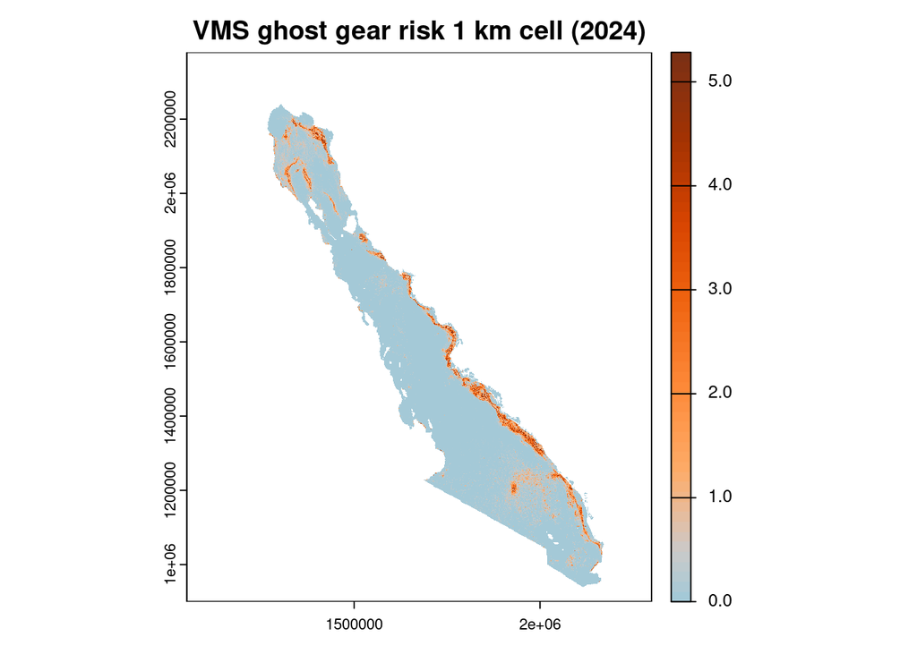

```r
ghost_risk_hours <- rast(file.path(
  PRESSURE_ROOT,
  "ghost_gear",
  "ghost_gear_risk_2024_1km.tif"
))

colors <- paletteer_c("ggthemes::Classic Orange-Blue", 100)[1:55]
q99_ghost <- quantile(values(ghost_risk_hours), 0.99, na.rm = TRUE)
plot(
  ifel(ghost_risk_hours > q99_ghost, 1, ghost_risk_hours),
  main = "VMS ghost gear risk 1 km cell (2024)",
  col = rev(colors)
)
```